# Exploratory analyses using Ernest 2005 data

```r
library(neonbecs)
# replicatebecs::download_raw_paper_data()
# replicatebecs::process_raw_data()
communities <- replicatebecs::load_paper_data()
```

#### generate ISDs

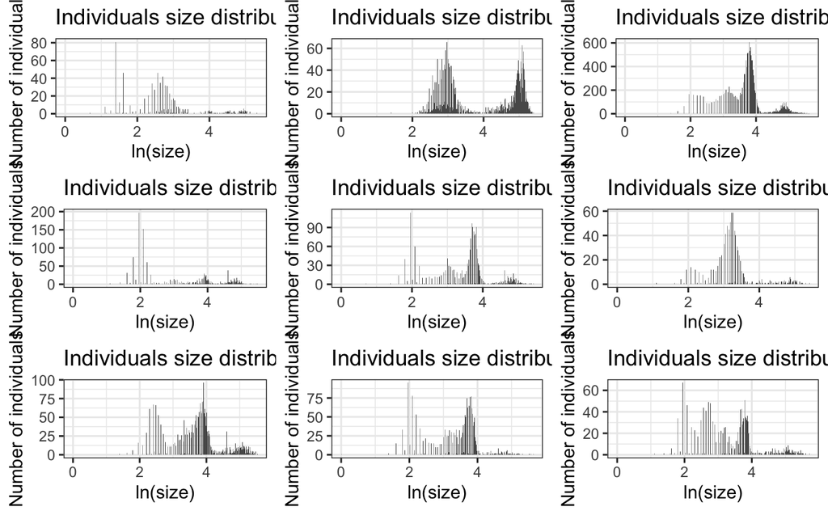

```r
communities_energy <- lapply(communities, replicatebecs::add_energy_sizeclass)
isds <- lapply(communities_energy, make_isd)
isd_plot <- lapply(isds, plot_isd)
gridExtra::grid.arrange(grobs = isd_plot, nrow = 3)
```

#### fit gmms

```r
gmms <- lapply(isds, fit_gmm)
```

#### integrate density and find peaks and pits

The output is obnoxious, sorry.

Green dots indicate local maxima; blue dots local minima. Red x’s surrounding blue dots denote boundaries of “gaps”, areas of the size spectrum where the density is <= 5% of the maximum density. No red x’s means no gaps.

Communities have 2-4 modes. Most communities have at least one gap (but see the fourth one, sev-5pgrass.)

The sixth one (sev-goatdraw) manages to have a mode that is at 5%?

[output not shown]

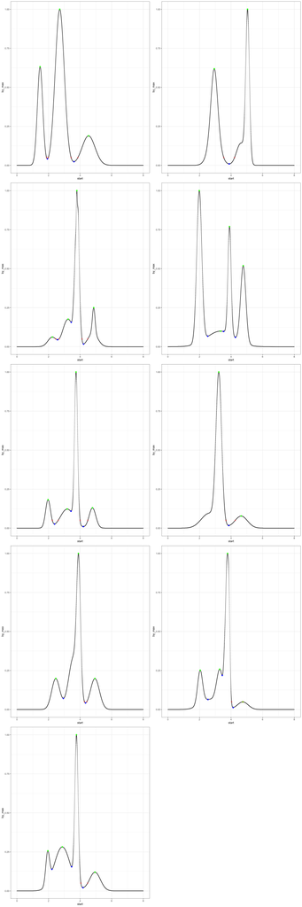

#### How many modes and troughs do communities have?

Points on the line will have the maximum number of troughs they could have given the number of modes. Most (6/9) communities fall below the line.

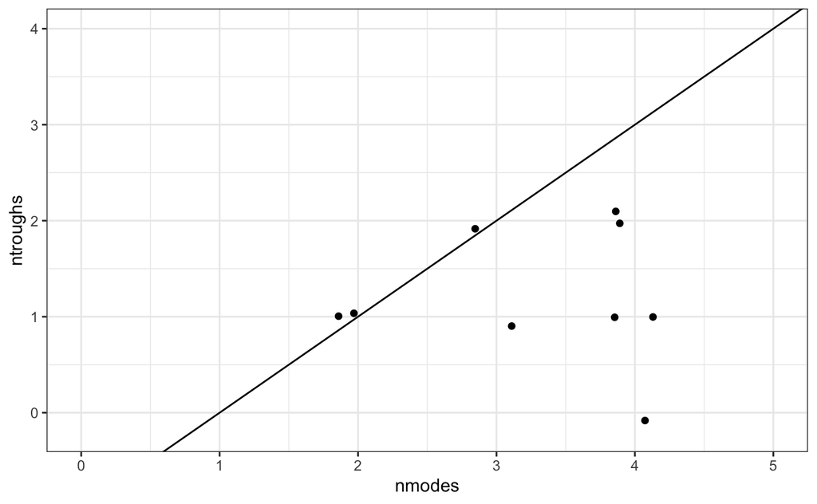

```r
community_stats <- data.frame(
  community_name= names(communities),
  nmodes = NA,
  ntroughs = NA
)
for(i in 1:nrow(community_stats)) {
  community_stats$nmodes[i] <- sum(integrated_densities[[i]]$start_is_peak)
    community_stats$ntroughs[i] <- sum(integrated_densities[[i]]$start_is_trough_start)
}
modes_troughs_plot <- ggplot2::ggplot(data = community_stats, ggplot2::aes(x = nmodes, y = ntroughs)) +
  ggplot2::ylim(-0.2, 4) +
  ggplot2::xlim(0, 5) +
  ggplot2::geom_jitter(inherit.aes = TRUE, width = .2, height = .1) +
  ggplot2::geom_abline(slope = 1, intercept = -1) +
  ggplot2::theme_bw()
modes_troughs_plot
```

#### Do species have means or tails in troughs?

Plotting species mean probability density against their size. Error bars are 1 standard deviation. Line is 5%.

If a species’ *mean* is below 5%, it is kind of a “gap specialist”. If only the tail of its standard deviation is below 5%, the individuals in the gap are unusually-improbably-sized for their species (juveniles, pregnant, maybe?).

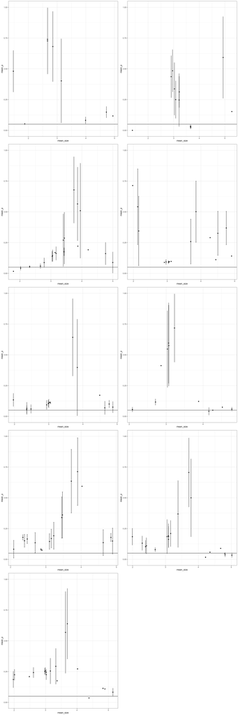

#### BSDs (for reference)

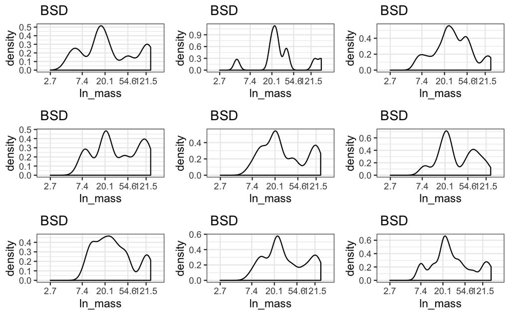

```r
bsds <-lapply(communities, replicatebecs::make_bsd)
bsd_plots <- lapply(bsds, replicatebecs::plot_bsd)
gridExtra::grid.arrange(grobs = bsd_plots, nrow = 3)
```